# Nasa Meta Data

Richard G. Gardiner

12/5/2018

# Intro

Disclosure: Most of the information below comes from *Text Mining with R* by David Robinson.

NASA has tens of thousands of datasets that cover everything from earth science to aeospace enginerring. We can use metadata for these datasets to understand how they all connect. The metadata includes the name of the dataset, description, which organization(s) is responsible for the dataset, and keywords. The metadata is publically available only in JSON format.

Using techniques like tf-idf and topic modeling, we will explose the connections between the different datasets.

# How the data is organized

The first we want to do is download the JSON file and look at the names of what is stored in the metadata

```r
library(jsonlite)

metadata <- fromJSON("https://data.nasa.gov/data.json")
names(metadata$dataset)
```

```
##  [1] "accessLevel"        "landingPage"        "issued"
##  [4] "@type"              "modified"           "keyword"
##  [7] "contactPoint"       "publisher"          "identifier"
## [10] "description"        "title"              "distribution"
## [13] "theme"              "bureauCode"         "programCode"
## [16] "license"            "temporal"           "references"
## [19] "spatial"            "accrualPeriodicity" "language"
## [22] "describedBy"        "describedByType"    "rights"
## [25] "dataQuality"
```

We see here that we could extract a lot of information from who publishes each dataset to what license they are released under. It seems likely that the title, description, and keywords for each dataset may be the best for connecting the datasets. Let’s check them out:

```r
class(metadata$dataset$title)
```

```
## [1] "character"
```

```r
class(metadata$dataset$description)
```

```
## [1] "character"
```

```r
class(metadata$dataset$keyword)
```

```
## [1] "list"
```

The title and description are stored as characters while the keyword is stored as a list.

## Wrangling and Tidying the data

Now we can set up tidy data frames for title, description, and keyword, keeping the data ids for each so we can connect them if necessary for later analysis

```r
library(tidyverse)
nasa_title <- data_frame(id = metadata$dataset$identifier,
                         title = metadata$dataset$title)

unique <- unique(nasa_title$id)
```

The book has a different way to capture the id, but it wasn’t working and this is the best idea I had for this. It appears that there may be a little bit of overlap, but that is going to have to do for now (the book also mentions overlap).

```r
nasa_description <- data_frame(id = metadata$dataset$identifier,
                               desc = metadata$dataset$description)

nasa_description %>%
  select(desc) %>%
  sample_n(5)
```

```
## # A tibble: 5 x 1
##   desc
##   <chr>
## 1 "Negative index materials (NIMs) offer tremendous potential for the for…
## 2 The proposed innovation is a robust, bio-inspired, and self-contained s…
## 3 "NEI Corporation and University of Florida propose to develop a mixed\n…
## 4 <p>Innovative research on superior catalytic cathode and solid state el…
## 5 Compact Terahertz Heterodyne Receivers, Phase II
```

Lastly, we will want to build a tidy data frame for the keywords. For this one, we need to use `unnest()` from tidyr, because they are in a list-column.

```r
nasa_keyword <- data_frame(id = metadata$dataset$identifier,
                          keyword = metadata$dataset$keyword) %>%
  unnest(keyword)

nasa_keyword
```

```
## # A tibble: 56,147 x 2
##    id                                        keyword
##    <chr>                                     <chr>
##  1 https://data.nasa.gov/api/views/f7qz-8dsr tomography
##  2 https://data.nasa.gov/api/views/f7qz-8dsr microct
##  3 TECHPORT_94241                            ames research center
##  4 TECHPORT_94241                            completed
##  5 TECHPORT_93206                            federal aviation administrat…
##  6 TECHPORT_93206                            active
##  7 TECHPORT_89174                            active
##  8 TECHPORT_94311                            arizona state university
##  9 TECHPORT_94311                            active
## 10 TECHPORT_71919                            active
## # ... with 56,137 more rows
```

This is a tidy data frame where each row is a keyword. This means there are multiple rows for most of the datasets.

Now we can use the `unnest_tokens()` function for the title and description fiedls so we can start doing text analysis. We will also remove stop from the descriptions and titles, but not the keywords because they are short-human assigned keywords.

```r
library(tidytext)

nasa_title <- nasa_title %>%
  unnest_tokens(word, title) %>%
  anti_join(stop_words)
nasa_description <- nasa_description %>%
  unnest_tokens(word, desc) %>%
  anti_join(stop_words)
```

Now they are in a tidy text format with one token (word) per row:

```r
nasa_title
```

```
## # A tibble: 132,989 x 2
##    id                                        word
##    <chr>                                     <chr>
##  1 https://data.nasa.gov/api/views/f7qz-8dsr ray
##  2 https://data.nasa.gov/api/views/f7qz-8dsr micro
##  3 https://data.nasa.gov/api/views/f7qz-8dsr tomography
##  4 https://data.nasa.gov/api/views/f7qz-8dsr micro
##  5 https://data.nasa.gov/api/views/f7qz-8dsr ct
##  6 TECHPORT_94241                            air
##  7 TECHPORT_94241                            traffic
##  8 TECHPORT_94241                            management
##  9 TECHPORT_94241                            atm
## 10 TECHPORT_94241                            technology
## # ... with 132,979 more rows
```

```r
nasa_description
```

```
## # A tibble: 1,639,649 x 2
##    id                                        word
##    <chr>                                     <chr>
##  1 https://data.nasa.gov/api/views/f7qz-8dsr ray
##  2 https://data.nasa.gov/api/views/f7qz-8dsr micro
##  3 https://data.nasa.gov/api/views/f7qz-8dsr tomography
##  4 https://data.nasa.gov/api/views/f7qz-8dsr micro
##  5 https://data.nasa.gov/api/views/f7qz-8dsr ct
##  6 https://data.nasa.gov/api/views/f7qz-8dsr destructive
##  7 https://data.nasa.gov/api/views/f7qz-8dsr imaging
##  8 https://data.nasa.gov/api/views/f7qz-8dsr technique
##  9 https://data.nasa.gov/api/views/f7qz-8dsr resolution
## 10 https://data.nasa.gov/api/views/f7qz-8dsr material
## # ... with 1,639,639 more rows
```

## Initial Analysis

Let’s get a list of the most common words in the dataset titles using dplyr.

```r
nasa_title %>%
  count(word, sort = TRUE)
```

```
## # A tibble: 11,499 x 2
##    word       n
##    <chr>  <int>
##  1 phase   8656
##  2 ii      2520
##  3 v1.0    1698
##  4 data    1663
##  5 system  1313
##  6 space   1011
##  7 based    795
##  8 low      645
##  9 2        632
## 10 mars     612
## # ... with 11,489 more rows
```

How about descriptions?

```r
nasa_description %>%
  count(word, sort = TRUE)
```

```
## # A tibble: 45,229 x 2
##    word           n
##    <chr>      <int>
##  1 data       14225
##  2 system     13058
##  3 phase      11698
##  4 space       9004
##  5 design      7571
##  6 technology  7385
##  7 based       7118
##  8 nasa        7099
##  9 systems     7033
## 10 nbsp        6660
## # ... with 45,219 more rows
```

Let’s remove some of the words that are used frequently, but are not meaningful to most of us. This can be done using a custom stop word then doing an anti join.

```r
my_stop_words <- data_frame(word = c(as.character(1:5),
                                 "ii", "v1.0", "l2", "l3", "1"))

nasa_title <- nasa_title %>%
  anti_join(my_stop_words)
nasa_description <- nasa_description %>%
  anti_join(my_stop_words)
```

What are the most common keywords?

```r
nasa_keyword %>%
  count(keyword, sort = TRUE)
```

```
## # A tibble: 6,781 x 2
##    keyword                          n
##    <chr>                        <int>
##  1 completed                     9021
##  2 active                        2885
##  3 goddard space flight center   1537
##  4 glenn research center         1535
##  5 langley research center       1390
##  6 jet propulsion laboratory     1317
##  7 ames research center          1226
##  8 johnson space center          1207
##  9 marshall space flight center   932
## 10 nasa                           651
## # ... with 6,771 more rows
```

This looks pretty good, but we might want to change all of our text to upper or lower case to get rid of duplicates when we do analysis:

```r
nasa_keyword <- nasa_keyword %>%
  mutate(keyword = toupper(keyword))
```

# Word co-ocurrences and correlations

Lets examine which words commonly occur together in the title,s descriptions, and keywords of NASA datasets. This may help us see which datasets are related to each other.

## Networks of description and title words

We can use `pairwise_count()` from widyr package to count how many time each pair of words occur together in a title or description field.

```r
library(widyr)

title_word_pairs <- nasa_title %>%
  widyr::pairwise_count(word, id, sort = TRUE, upper = FALSE)

title_word_pairs
```

```
## # A tibble: 207,408 x 3
##    item1    item2       n
##    <chr>    <chr>   <dbl>
##  1 phase    system    948
##  2 space    phase     637
##  3 based    phase     601
##  4 phase    low       480
##  5 phase    power     441
##  6 systems  phase     421
##  7 phase    control   416
##  8 phase    sensor    403
##  9 advanced phase     362
## 10 orbiter  rosetta   361
## # ... with 207,398 more rows
```

These are pairs of words that occur together most often in title fields. We see a lot of “phase” in this top 10. Now let’s do the same with descriptions:

```r
desc_word_pairs <- nasa_description %>%
  widyr::pairwise_count(word, id, sort = TRUE, upper = FALSE)

desc_word_pairs
```

```
## # A tibble: 18,523,060 x 3
##    item1      item2       n
##    <chr>      <chr>   <dbl>
##  1 system     phase    2430
##  2 systems    system   2367
##  3 system     develop  2276
##  4 based      system   2259
##  5 space      system   2172
##  6 technology system   2145
##  7 nasa       system   2114
##  8 design     system   2095
##  9 develop    phase    2087
## 10 nasa       phase    2073
## # ... with 18,523,050 more rows
```

As with titles, the word “phase” and “system” are pretty common.

Let’s plot networks of these cooccurring words so we can see these relationships better. We will use the ggraph package to visualize the networks:

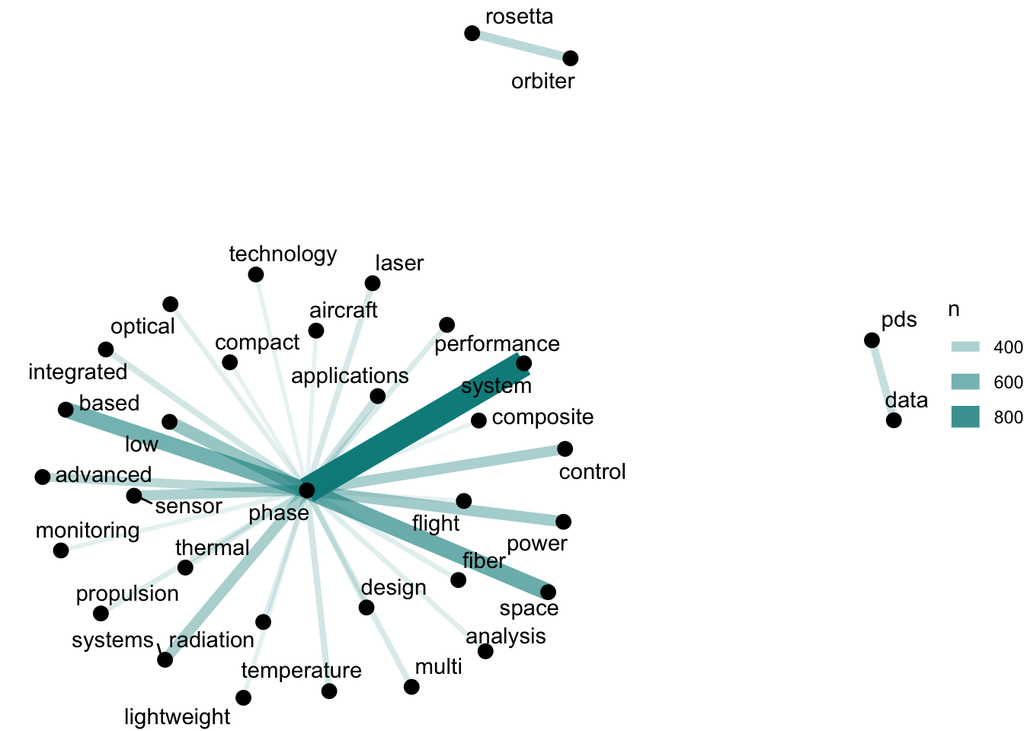

```r
library(ggplot2)
library(igraph)
library(ggraph)


set.seed(1234)
title_word_pairs %>%
  filter(n >= 200) %>%
  graph_from_data_frame() %>%
  ggraph(layout = "fr") +
  geom_edge_link(aes(edge_alpha = n, edge_width = n), edge_colour = "cyan4") +
  geom_node_point(size = 3) +
  geom_node_text(aes(label = name), repel = TRUE,
                 point.padding = unit(0.2, "lines")) +
  theme_void()
```

So phase clearly is the key part of this. Perhaps it is actually too important, but we can deal with that later. It might be more helpful to do tf-idf as a metric to find characteristic words for each description field. Let’s look at the description fields:

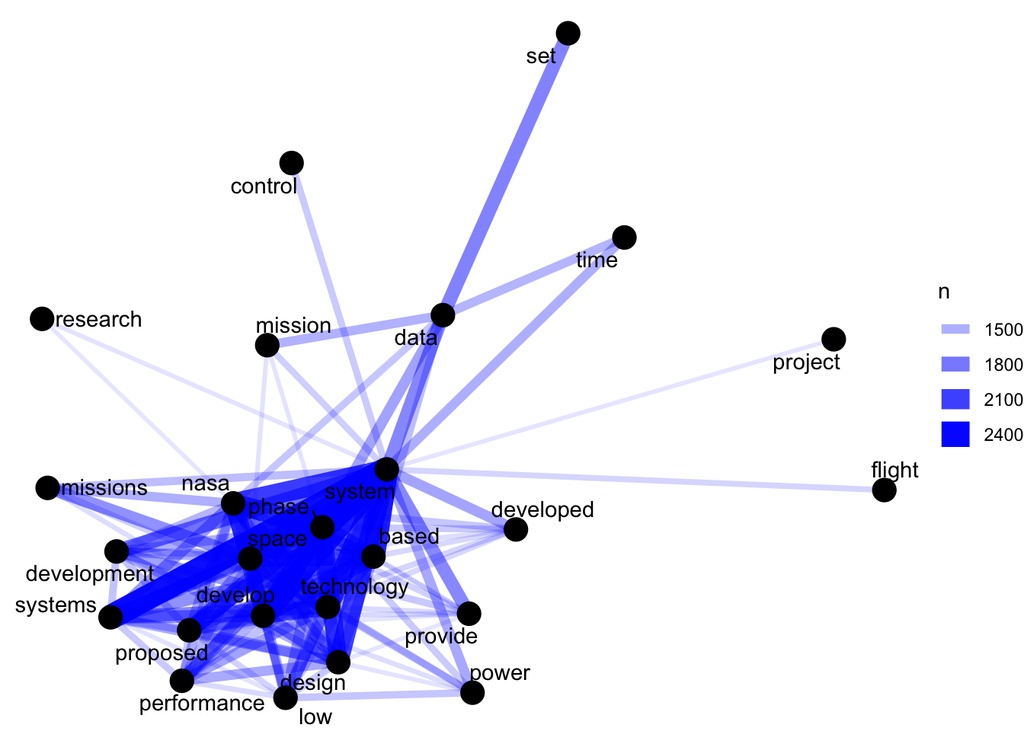

```r
set.seed(1234)
desc_word_pairs %>%
  filter(n >= 1200) %>%
  graph_from_data_frame() %>%
  ggraph(layout = "fr") +
  geom_edge_link(aes(edge_alpha = n, edge_width = n), edge_colour = "blue") +
  geom_node_point(size = 5) +
  geom_node_text(aes(label = name), repel = TRUE,
                 point.padding = unit(0.2, "lines")) +
  theme_void()
```

This is showing a more complex network (though I had to play with the filter).

Now let’s do networks of keywords:

```r
keyword_pairs <- nasa_keyword %>%
  pairwise_count(keyword, id, sort = TRUE, upper = FALSE)

keyword_pairs
```

```
## # A tibble: 1,997,193 x 3
##    item1                item2                            n
##    <chr>                <chr>                        <dbl>
##  1 COMPLETED            GLENN RESEARCH CENTER         1300
##  2 COMPLETED            GODDARD SPACE FLIGHT CENTER   1249
##  3 COMPLETED            LANGLEY RESEARCH CENTER       1130
##  4 COMPLETED            JOHNSON SPACE CENTER          1049
##  5 AMES RESEARCH CENTER COMPLETED                     1037
##  6 COMPLETED            JET PROPULSION LABORATORY     1007
##  7 COMPLETED            MARSHALL SPACE FLIGHT CENTER   757
##  8 DASHLINK             AMES                           644
##  9 DASHLINK             NASA                           644
## 10 AMES                 NASA                           644
## # ... with 1,997,183 more rows
```

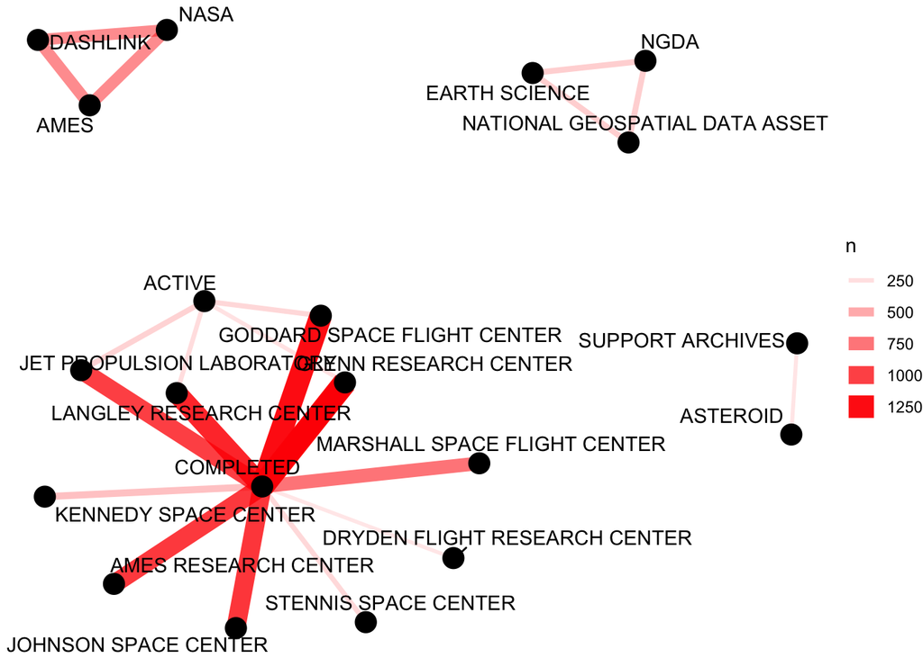

```r
set.seed(1234)
keyword_pairs %>%
  filter(n >= 200) %>%
  graph_from_data_frame() %>%
  ggraph(layout = "fr") +
  geom_edge_link(aes(edge_alpha = n, edge_width = n), edge_colour = "red") +
  geom_node_point(size = 5) +
  geom_node_text(aes(label = name), repel = TRUE,
                 point.padding = unit(0.2, "lines")) +
  theme_void()
```

NOTE: these are the most common keywords occuring together, but they are also in general the most common keywords.

We can also do pairwise correlation with keywords to see which keywords that are more likely to occur together than other keywords.

```r
keyword_cor <- nasa_keyword %>%
  group_by(keyword) %>%
  filter(n() >= 50) %>%
  pairwise_cor(keyword, id, sort = TRUE, upper = FALSE)

keyword_cor
```

```
## # A tibble: 6,555 x 3
##    item1      item2                          correlation
##    <chr>      <chr>                                <dbl>
##  1 NGDA       NATIONAL GEOSPATIAL DATA ASSET       1.
##  2 DASHLINK   AMES                                 1.
##  3 KNOWLEDGE  SHARING                              1
##  4 SCHEDULE   EXPEDITION                           1
##  5 TURBULENCE MODELS                               0.997
##  6 APPEL      KNOWLEDGE                            0.997
##  7 APPEL      SHARING                              0.997
##  8 DASHLINK   NASA                                 0.994
##  9 AMES       NASA                                 0.994
## 10 CLOUD      ATMOSPHERIC SCIENCE                  0.994
## # ... with 6,545 more rows
```

Note that we have a few that always occur together (correlation of 1). This means that they are redundant keywords. We can visualize a network of keyword correlations just like the co-occurences.

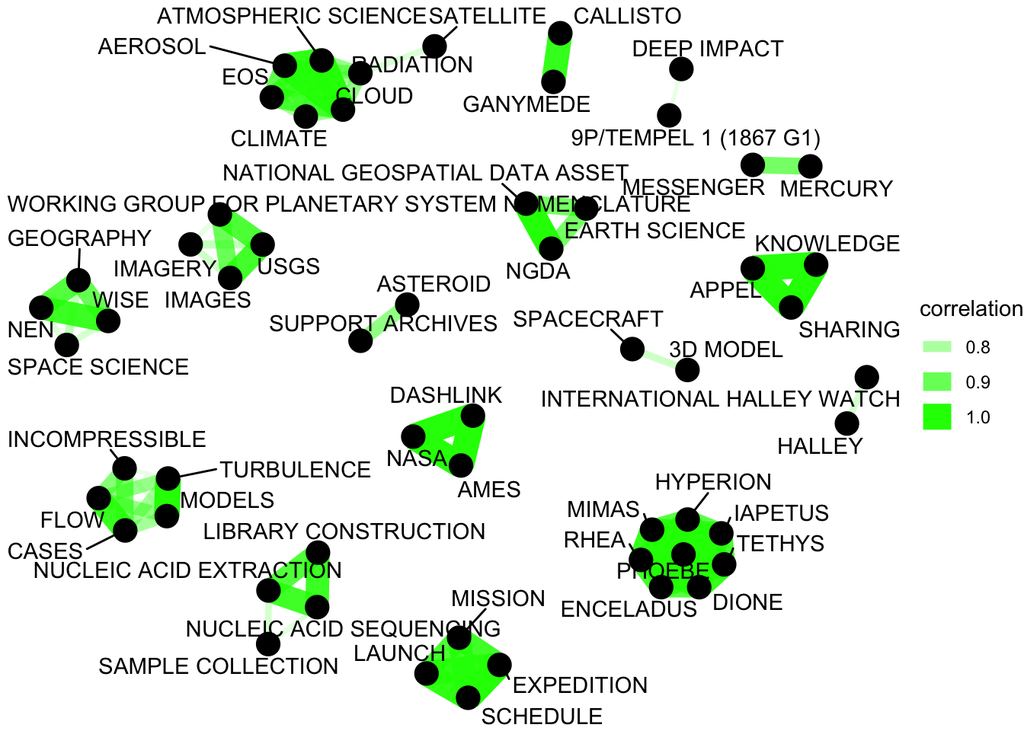

```r
set.seed(1234)
keyword_cor %>%
  filter(correlation > .7) %>%
  graph_from_data_frame() %>%
  ggraph(layout = "fr") +
  geom_edge_link(aes(edge_alpha = correlation, edge_width = correlation), edge_colour = "green") +
  geom_node_point(size = 5) +
  geom_node_text(aes(label = name), repel = TRUE,
                 point.padding = unit(0.2, "lines")) +
  theme_void()
```

This is rather interesting and different than the co=occurences network. The main difference is that this graph is asking about which keyword pairs occur more oten together than with other words. In this network, there are a lot of clusters that are independent of each other. This can be extracted for further analysis.

# Calculating tf-idf for the description fields

The results of the pairwise count for the descriptions showed that there are just a few words that dominate the fields. In this instance, using tf-idf would be great to find words that are espeically important to a document within a collection of documents. For this example, we will consider each description field a “document” and the entire dataframe as the colelction (corpus) of documents. Since we have already used the `unnest_tokens()` function, we only need to use the `bind_tf_idf()` function:

```r
desc_tf_idf <- nasa_description %>%
  count(id, word, sort = TRUE) %>%
  ungroup() %>%
  bind_tf_idf(word, id, n)
```

```r
desc_tf_idf %>%
  arrange(-tf_idf)
```

```
## # A tibble: 1,150,782 x 6
##    id             word             n    tf   idf tf_idf
##    <chr>          <chr>        <int> <dbl> <dbl>  <dbl>
##  1 TECHPORT_33575 abcd             1     1  9.76   9.76
##  2 TECHPORT_94546 xxxx             1     1  9.76   9.76
##  3 TECHPORT_94119 aerosciences     1     1  8.66   8.66
##  4 NASA-438       lgrs             1     1  7.68   7.68
##  5 NASA-446       lgrs             1     1  7.68   7.68
##  6 NASA-463       lgrs             1     1  7.68   7.68
##  7 NASA-432       sharad           1     1  6.32   6.32
##  8 NASA-433       sharad           1     1  6.32   6.32
##  9 NASA-435       sharad           1     1  6.32   6.32
## 10 NASA-603       sharad           1     1  6.32   6.32
## # ... with 1,150,772 more rows
```

These are teh mostimportant words in teh description fields as measured by tf-idf. Note that in many fields we have an “n” of 1 and a “tf” of 1 meaning that these were descrption finds that only had a single word in them. If a document only has one word, the tf-idf algorithm wil think that it is a very important word.

## Connecting description fields to keywords

Now let’s plot some of hte most important words, as measured by tf-idf, for a few example keywords used on NASA datasets. First, we will use dplyr operations to filter for keywords we want to examine and look at the top 15 words for each keyword:

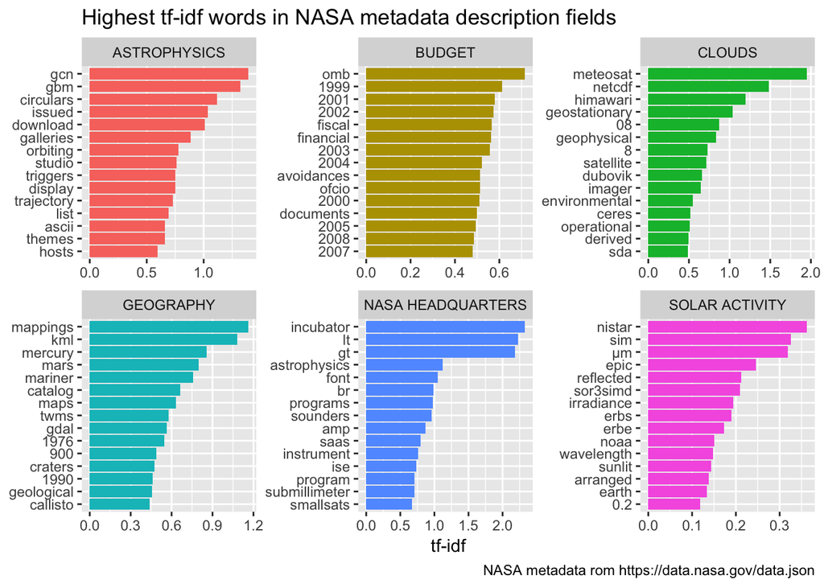

```r
desc_tf_idf <- full_join(desc_tf_idf, nasa_keyword, by = "id")


desc_tf_idf %>%
  filter(!near(tf, 1)) %>%
  filter(keyword %in% c("SOLAR ACTIVITY", "CLOUDS", "NASA HEADQUARTERS",
                        "ASTROPHYSICS", "GEOGRAPHY", "BUDGET")) %>%
  arrange(desc(tf_idf)) %>%
  group_by(keyword) %>%
  distinct(word, keyword, .keep_all = TRUE) %>%
  top_n(15, tf_idf) %>%
  ungroup() %>%
  mutate(word = factor(word, levels = rev(unique(word)))) %>%
  ggplot(aes(word, tf_idf, fill = keyword)) +
  geom_col(show.legend = FALSE) +
  facet_wrap(~keyword, ncol = 3, scales = "free") +
  coord_flip() +
  labs(title = "Highest tf-idf words in NASA metadata description fields",
       caption = "NASA metadata rom https://data.nasa.gov/data.json",
       x = NULL, y = "tf-idf")
```

These graphs show us good validity for the tf-idf scores we have developed. The budget one shows us financial information, OMB, and years. Geography shows thing we would expect like mapping, maps, and geoogical. This would help us discover datasets we might want to consider (or searches for datasets).

# Topic Modeling

The tf-idf scores did give us some insight into the content of the different description fields, but we can try another approach to find out what hte description fields are about. We can use topic modeling to model each document (description field) as a mixture of topics and each topic as a mixtrue of words. We are doing to latent Dirichlet allocation (LDA), even though there are multiple options for this.

## Casting to a Document-Term Matrix (DTM)

We need to turn our tidy data into a document term matrix using the `cast_dtm()` function from tidytext package. Rows in this format correspond to doucments and columns correstond to terms (words); it is a sparse matri and the values are word counts.

```r
custom_stop_word <- bind_rows(stop_words,
                           data_frame(word = c("nbsp", "amp", "gt", "lt",
                                               "timesnewromanpsmt", "font",
                                               "td", "li", "br", "tr", "quot",
                                               "st", "img", "src", "strong",
                                               "http", "file", "files",
                                               as.character(1:12)),
                                      lexicon = rep("custom", 30)))
word_counts <- nasa_description %>%
  anti_join(my_stop_words) %>%
  count(id, word, sort = TRUE) %>%
  ungroup()
word_counts
```

```
## # A tibble: 1,150,782 x 3
##    id             word      n
##    <chr>          <chr> <int>
##  1 TECHPORT_40635 nbsp    207
##  2 TECHPORT_10853 gt      191
##  3 TECHPORT_10853 lt      190
##  4 TECHPORT_10853 font    158
##  5 DASHLINK_425   td      128
##  6 TECHPORT_90800 nbsp    128
##  7 TECHPORT_91008 nbsp    121
##  8 TECHPORT_14572 gt       96
##  9 TECHPORT_14572 lt       96
## 10 TECHPORT_73    gt       94
## # ... with 1,150,772 more rows
```

This is the information we need, the number of times each word is used in each document, now we can `cast()` from out tidy text into the dtm format.

```r
desc_dtm <- word_counts %>%
  cast_dtm(id, word, n)

desc_dtm
```

```
## <<DocumentTermMatrix (documents: 17308, terms: 45220)>>
## Non-/sparse entries: 1150782/781516978
## Sparsity           : 100%
## Maximal term length: 166
## Weighting          : term frequency (tf)
```

We can see that we have the correct number of documents, that this is pretty much 100% spare, meaning that almost all of the entries in this matrix are zero. Each non-zero entry corresponds to a cetain word appearing in a certain document.

### Ready for Topic Modeling

Now we can use the topimodels package to create the LDA model. We don’t know ahead of time how many topics we want, just like k-means clustering. The authors tried a number of topics (8, 16, 24, 32, and 64), but found that 24 topics is the best. AT 24 the documents are getting sorted into topics cleanly, but going much beyond that caused the distributions of $\gamma$, the probability that eacch document belongs in each topic, to look worrisome (something to be discussed later).

```r
library(topicmodels)

# this will take a long time to run this model (over 30 minutes now):
desc_lda <- LDA(desc_dtm, k = 24, control = list(seed = 1234))
```

The seed control is only here to get same results as the authors. This is because the stochastic algorithm could have different results depending on where the algorithm started. Thus we had to specify a `seed`.